# WHAT ON EARTH ARE LOG FUNCTIONS

## ...and why are you making me think about them?

- The next lab works with something called **log probabilities**
- No log jokes please

[figure not shown]

## THE PLAN

- I will (try to) *explain* log functions (and why we're using them)...
- at **three levels of detail**.

## THE PLAN

The levels of detail are:

1) **I hate and fear log functions**, is this a problem?

2) I want to know **why we're using log functions**, with minimal mathematics.

3) Maths is just super, and there's a good chance I already understand log functions, but...

**I want to see how linguists do maths**.

## THE PLAN

**IMPORTANT: Level 1 is enough to do everything on this course**.

- Everything else is to support your understanding...
- ...*if* you think that helps.
- I will...
  - leave these slides up
  - put a notebook of these slides on Noteable and the website
  - you can always come back later.

## THE PLAN

- I will go through each level of detail:
  - You can stop at any point and come back later
    - (or not come back at all)
  - Everything is going to be OK.

[figure not shown]

## LEVEL ONE

### Q: I hate and fear log functions, is this going to be a problem?

### A: No

- This is not a problem at all.
- Many historical figures hated and feared logarithms and went on to do great things.

### Q: So what do I need to do?

### A: Just ignore the word 'log'

- Whenever you see a log function, just pretend the word isn't there.
- It's all just probability stuff, except with a trick to make it work on computers.

That's it! But would you like to know a *little* more?

## LEVEL TWO

### Q: Actually, can you tell me why we use these log things? With minimal mathematics please?

### A: OK then

We **multiply** probabilities for **multiple events**.

Look at these awesome dice:

[figure not shown]

- The dice have 20 sides each, so...
- The probability of rolling *one* of them...
- and getting a **20** is:
  - $\frac{1}{20}$, or 0.05 as a decimal.
- the probability of rolling *both* and getting **two** 20s is:
  - $\frac{1}{20}$ X $\frac{1}{20}$ = $\frac{1}{400}$

When you **multiply** probabilities they get **really small**

- $\frac{1}{400}$ is way smaller than $\frac{1}{20}$
- Written as a decimal, it's 0.0025

What if we roll **100 dice?**

- What's the probability of getting **all 20s**?
- It's $\frac{1}{20}$ X $\frac{1}{20}$ X $\frac{1}{20}$ X $\frac{1}{20}$ *etc etc and on and on...*
- until we've done it a hundred times.
- A better way to write this is $\frac{1}{20^{100}}$
- What is it written in decimal?
- Let's **get Python to do the maths**:

## The maths

What is $\frac{1}{20^{100}}$ written in decimal?

```python
1/(20**100)
```

```
7.888609052210118e-131
```

**How small** is that number?

- Another way to write the number above is 7.9 x $10^{-131}$
- Written out in full, that's 0.000000000000000000000000000000000000000000000000000000000000000000000000000000000000000000000000000000000000000000000000000000000079
- That's a **really really** small number.

What does 7.9 x $10^{-131}$ mean in terms of *probability*?

To give an **extremely natural and relatable example**:

- it's roughly the same probability as...
- two people
- each pick out a **single sub-atomic particle**
- **at random** from anywhere in the **entire known universe**
- and choosing the same one...
- **by chance**

What's the lesson here?

- Once you start combining probabilistic events and observations
- the chance of any *particular* event...
- becomes *very very* small...
- ...very very quickly.

That's really very interesting thank you so much, but why should I care?

- Let's roll some more dice!
- Exactly 249 of them in fact, for no particular reason.
- What are the chances of rolling 249 dice and getting all 20s?
  - Written the fancy way: $\frac{1}{20^{249}}$
  - And written in decimal?

```python
1/(20**249)
```

```
0.0
```

```python
1/(20**249)
```

```
0.0
```

We **broke Python**

- Python has some clever ways of representing very small numbers, but only up to a point.
- After that point, it just **gives up** and breaks.
- This is **not ideal**.

**Log functions are a way for Python to deal with really really small numbers.**

- That's the most important lesson, really.
- Once numbers get really small, Python starts to **break in weird ways**.
- We use logarithms (i.e. log functions) to convert really small numbers into something Python can deal with.
- When you see the log functions in the notebook, that's all they're doing.

**When** do we use log functions?

In general, the procedure works like this:

1) Turn all the probabilities into log-probabilities

2) Do all the math stuff using the log-probabilities (so Python doesn't break in weird ways)

3) When all the math stuff is finished, turn the log-probabilities back into normal probabilities.

That's it! Onwards...

# Level 3

## Give me the maths

Here's what you need to know:

## Logarithmic scale

Here are the awesome dice again!

[figure not shown]

We can plot the probability of getting **all 20s** for increasing numbers of dice:

[output not shown]

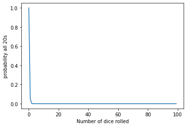

```python
dice_probs = []
for i in range(100):
    dice_probs.append(1/(20**i))
plt.plot(dice_probs)
plt.ylim(-0.05,1.05)
plt.ylabel('probability all 20s')
plt.xlabel('Number of dice rolled')
```

That's incredibly boring and unhelpful: the probabilities get super small really quickly

What if we plot the **logarithm** of the probabilities?

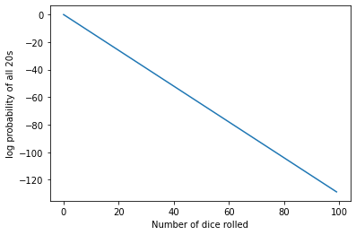

```python
dice_logprobs = []
for p in dice_probs:
    dice_logprobs.append(np.log10(p))
plt.plot(dice_logprobs)
plt.ylabel('log probability of all 20s')
plt.xlabel('Number of dice rolled')
```

It's still a bit boring, but now it decreases **linearly**

Logarithms scale over **orders of magnitude**

- For numbers bigger than 1, that means that:
  - 1, 10, 100, 1000, 10000, ... $10^{big number}$
- Have logarithms (in base 10) of:
  - 0, 1, 2, 3, 4, ... $big number$
- For numbers between 1 and 0, that means that:
  - $\frac{1}{1}$, $\frac{1}{10}$, $\frac{1}{100}$, $\frac{1}{1000}$, $\frac{1}{10000}$, ... $\frac{1}{1^{huge number}}$
- Have logarithms (in base 10) of:
  - 0, -1, -2, -3, -4, -$huge number$

That's why logarithm-transformed numbers are easier for computers to represent.

## Logarithms are the inverse of exponents

Remember:

1. We take the logarithm of some probabilities
2. We do a bunch of maths
3. We convert the log-probabilities back into normal probabilities

How do we do the last bit?

We convert back by using the log-probability as the exponent

```python
probs = [1, 0.1, 0.01, 0.001, 0.0001, 10**-42]
print('Initial probs:    ', probs)
log_probs = []
converted_probs = []
for p in probs:
    log_probs.append(np.log10(p))
print('Log probabilities:', log_probs)
for lp in log_probs:
    converted_probs.append(10**lp)
print('Converted back:   ', converted_probs)
```

```
Initial probs:     [1, 0.1, 0.01, 0.001, 0.0001, 1e-42]
Log probabilities: [0.0, -1.0, -2.0, -3.0, -4.0, -42.0]
Converted back:    [1.0, 0.1, 0.01, 0.001, 0.0001, 1e-42]
```

## Logarithms change the Operators

Remember:

1. We take the logarithm of some probabilities
2. We do a bunch of maths
3. We convert the log-probabilities back into normal probabilities

We still haven't talked about the bit where we do the maths!

## Logarithms change the Operators

It's really simple:

1. Multiplication $\rightarrow$ Addition
2. Division $\rightarrow$ Subtraction

Because we changed the scale (to orders of magnitude),

- the operators become:
  1. simpler
  2. easier on the computer
  3. prevent weird errors

```python
prob_a = 1/(10**50)
prob_b = 1/(10**60)
prob_a * prob_b
```

```
1e-110
```

Now converting into log-probabilities, *adding*, and converting *back* into normal probability:

```python
logprob_a = np.log10(prob_a)
logprob_b = np.log10(prob_b)
log_product = logprob_a + logprob_b
10**log_product
```

```
1e-110
```

We get the same result! But why should I care?

## An example of why we should care

When we're doing stuff with Bayesian probability, most of the time:

- We don't care about the *actual* probability that something will happen
- The actual probability something will happen is **extremely small**

Instead, we usually want to **compare** probabilities, for example:

- I need to choose between A and B
- Individually, both A and B are highly unlikely
- But is A is 100 times as likely as B, I should choose A

Let's see this in action:

```python
prob_A = 10**-100 * 10**-150 * 10**-200
prob_B = 10**-100 * 10**-150 * 10**-202
```

- We want to compare the likelihood of A and B.
- What will happen if we divide A by B?

```python
prob_A / prob_B
```

```
---------------------------------------------------------------------------
ZeroDivisionError                         Traceback (most recent call last)
<ipython-input-64-7084ccd17c93> in <module>
----> 1 prob_A / prob_B

ZeroDivisionError: float division by zero
```

Disaster!

## Logs to the rescue

- We can still divide A by B
- Using **logs** of course!

```python
logprob_A = np.log10(10**-100) + np.log10(10**-150) + np.log10(10**-200)
logprob_B = np.log10(10**-100) + np.log10(10**-150) + np.log10(10**-202)
logratio = logprob_A - logprob_B
ratio = 10**logratio
print('The probability ratio of A/B=', ratio)
```

```
The probability ratio of A/B= 100.0
```

And that's pretty much it!